# Assignment9

Mary Anna Kivenson

April 26, 2020

# Assignment 9

Do problems 8.1, 8.2, 8.3, and 8.7 in Kuhn and Johnson.

## Question 8.1

Recreate the simulated data from Exercise 7.2:

```r
set.seed(200)
simulated <- mlbench.friedman1(200, sd = 1)
simulated <- cbind(simulated$x, simulated$y)
simulated <- as.data.frame(simulated)
colnames(simulated)[ncol(simulated)] <- "y"
```

1. Fit a random forest model to all of the predictors, then estimate the variable importance scores:

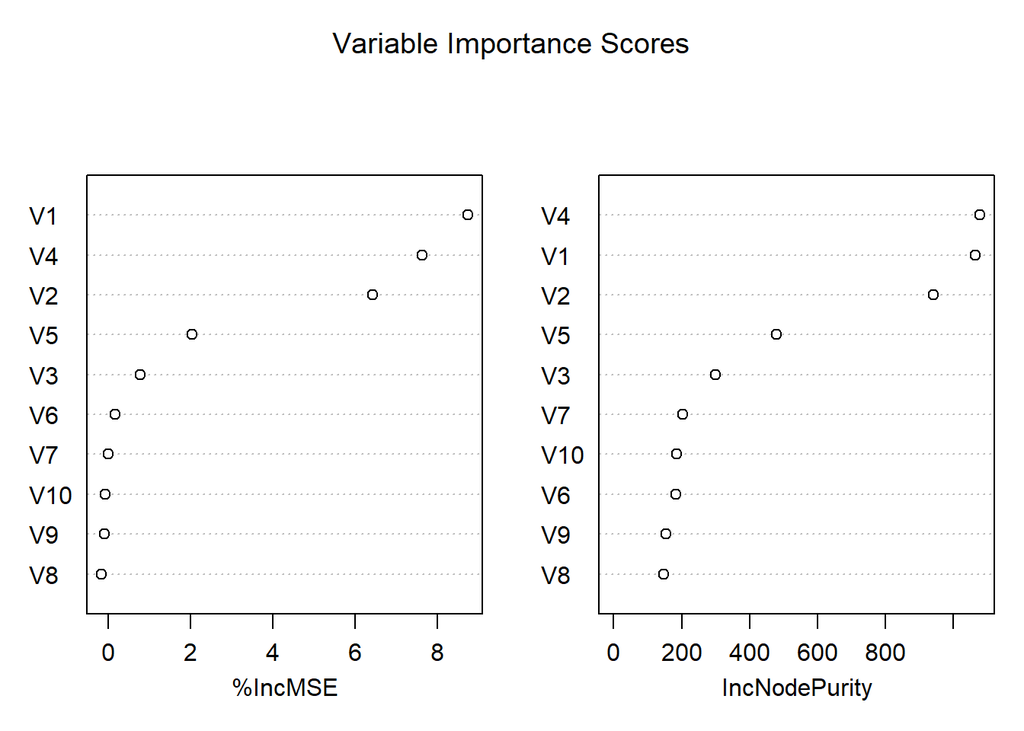

```r
model1 <- randomForest(y ~ ., data = simulated, importance = TRUE, ntree = 1000)
rfImp1 <- varImp(model1, scale = FALSE)
varImpPlot(model1, main = 'Variable Importance Scores', scale = FALSE)
```

Did the random forest model signiﬁcantly use the uninformative predictors (V6 – V10)?

The model used the uninformative predictors less than the informative predictors; V6 - v10 were in the bottom half of the variable importance ranking.

2. Now add an additional predictor that is highly correlated with one of the informative predictors. For example:

```r
simulated$V1_DUP1 <- simulated$V1 + rnorm(200) * .1
cor(simulated$V1_DUP1, simulated$V1)
```

```
## [1] 0.9460206
```

Fit another random forest model to these data. Did the importance score for V1 change? What happens when you add another predictor that is also highly correlated with V1?

The importance score for V1 decreased from first most important predictor to third.

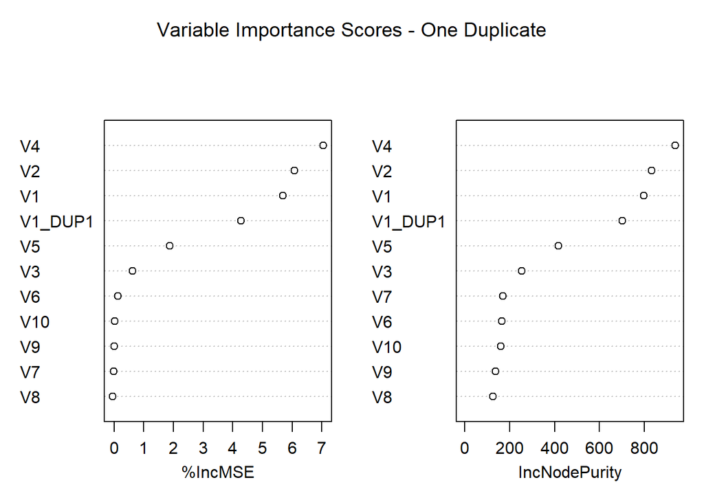

```r
model2 <- randomForest(y ~ ., data = simulated, importance = TRUE, ntree = 1000)
varImpPlot(model2, main = 'Variable Importance Scores - One Duplicate', scale = FALSE)
```

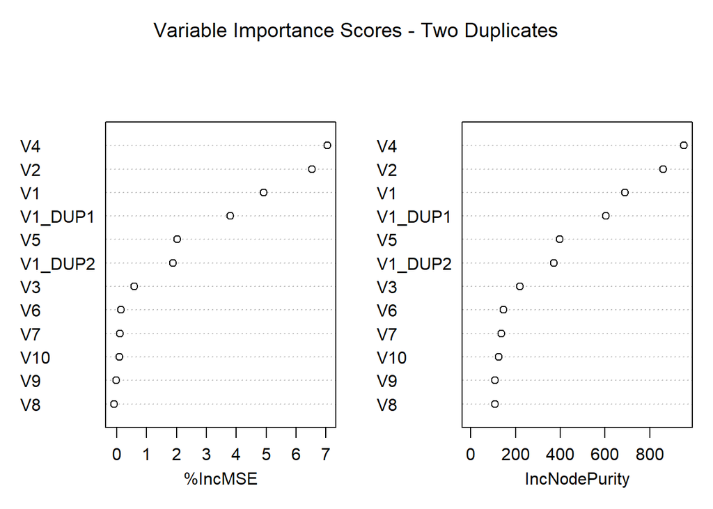

```r
simulated$V1_DUP2 <- simulated$V1 + rnorm(200) * .1
model3 <- randomForest(y ~ ., data = simulated, importance = TRUE, ntree = 1000)
varImpPlot(model3, main = 'Variable Importance Scores - Two Duplicates', scale = FALSE)
```

3. Use the cforest function in the party package to ﬁt a random forest model using conditional inference trees. The party package function varimp can calculate predictor importance. The conditional argument of that function toggles between the traditional importance measure and the modiﬁed version described in Strobl et al. (2007). Do these importances show the same pattern as the traditional random forest model?

The importances between the traditional measure and the modified measure are similar. The unimportant features, V6-V10, are still ranked low and the relative order of predictor importance is similar. The main difference is that the absolute importance measure of the highly correlated features, V1_DUP1 and V1_DUP2 are lower in the modified version.

```r
set.seed(100)
cfmodel <- cforest(y ~ ., data=simulated)
varimps <- cbind(varimp(cfmodel), varimp(cfmodel, conditional = TRUE))
colnames(varimps) <- c('traditional', 'modified')
variable <- cbind(rownames(varimps))
varimps %>% as.data.frame(index) %>% cbind(variable) %>% arrange(desc(traditional))
```

```
##    traditional     modified variable
## 1   7.14871626  5.586613034       V4
## 2   6.06638288  4.774816450       V2
## 3   4.54761845  1.512667321  V1_DUP1
## 4   3.91965632  1.514490668       V1
## 5   1.46016158  0.948024158       V5
## 6   1.28202941  0.364336221  V1_DUP2
## 7   0.07973182  0.029361880       V7
## 8   0.02162509  0.006428241       V9
## 9   0.01284779  0.018175387       V3
## 10 -0.01297780  0.016908087       V6
## 11 -0.01349482  0.007446268       V8
## 12 -0.02027465 -0.028254237      V10
```

4. Repeat this process with different tree models, such as boosted trees and Cubist. Does the same pattern occur?

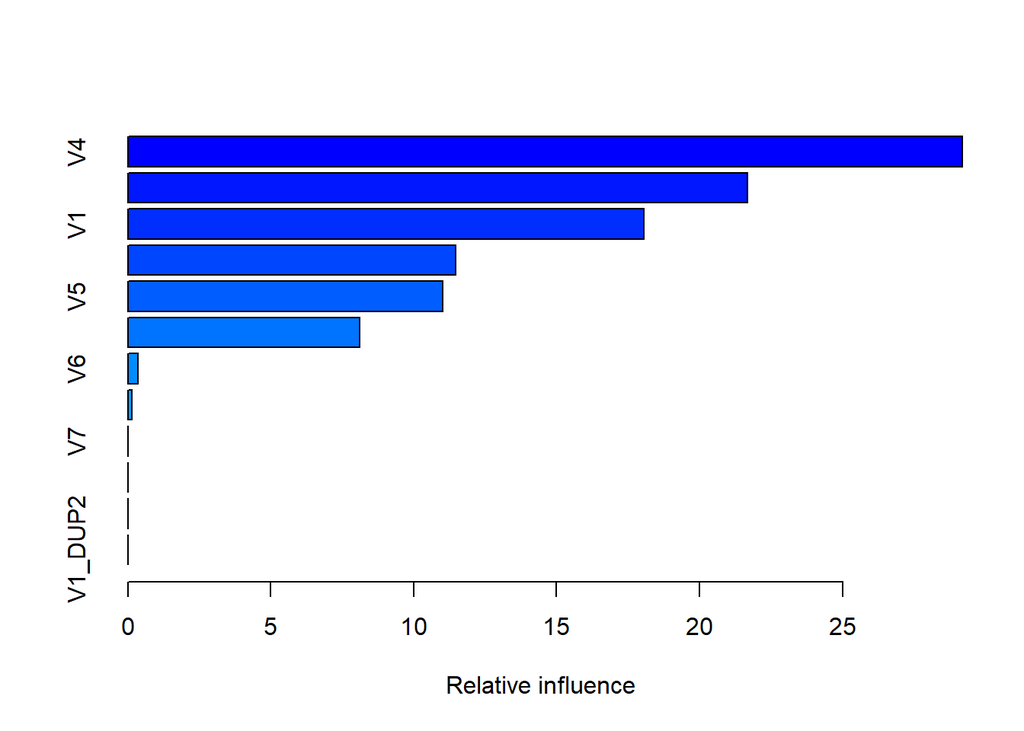

```
##        var    rel.inf
## 1       V4 29.1939732
## 2       V2 21.6710540
## 3       V1 18.0439640
## 4  V1_DUP1 11.4654583
## 5       V5 11.0231835
## 6       V3  8.1169308
## 7       V6  0.3440822
## 8       V9  0.1413541
## 9       V7  0.0000000
## 10      V8  0.0000000
## 11     V10  0.0000000
## 12 V1_DUP2  0.0000000
```

```r
#BOOSTED TREES
library(gbm)
gbmModel <- gbm(y ~ ., data=simulated, distribution='gaussian')
summary(gbmModel) %>% arrange(desc(rel.inf))
```

The cubist model also ranks predictos V6-V10 low on the importance list. It also does a good job of ranking V1 highly and ranking V1’s correlated predictors lower on the list.

```r
#CUBIST
library(Cubist)
cubistMod <- cubist(simulated[-11], simulated$y, committees = 100)
imp <- as.data.frame(varImp(cubistMod))
imp <- data.frame(overall = imp$Overall,
           names   = rownames(imp))
imp[order(imp$overall,decreasing = T),]
```

```
##    overall   names
## 3     63.0      V2
## 1     50.5      V1
## 2     50.5      V3
## 5     46.0      V4
## 6     28.5 V1_DUP1
## 8     28.5      V5
## 4     20.5 V1_DUP2
## 9      8.5      V6
## 7      3.5      V8
## 10     0.0      V7
## 11     0.0      V9
## 12     0.0     V10
```

Finally, the bagged trees model also ranks predictors V6-V10 low on the importance list. It assigns V1 and V1_DUP1 similar importance levels, below V4, V5, and V2.

```r
#BAGGED TREES
library(ipred)
baggedTree <- bagging(y ~ ., data = simulated)
imp <- as.data.frame(varImp(baggedTree))
imp <- data.frame(overall = imp$Overall,
           names   = rownames(imp))
imp[order(imp$overall,decreasing = T),]
```

```
##      overall   names
## 7  2.7057087      V4
## 8  2.3482671      V5
## 5  2.0815556      V2
## 1  1.7447769      V1
## 2  1.6720775 V1_DUP1
## 3  1.2186668 V1_DUP2
## 6  1.0675952      V3
## 10 1.0474691      V7
## 9  0.7735715      V6
## 4  0.7059297     V10
## 12 0.6092801      V9
## 11 0.5826224      V8
```

## Question 8.2

Use a simulation to show tree bias with different granularities.

Trees may suffer from selection bias, which means that predictors with more distinct values are favored over granular predictors.

To test different granularities, two predictors will be created - one with 2 distinct values, and one with 100 distinct values. The result variable will be a product of the two variables.

```r
V1 <- floor(runif(100, min=0, max=2)) #BINARY COLUMN, ONLY 2 DISTINCT VALUES
V2 <- (runif(100, min=0, max=1)) #100 DISTINCT VALUES
```

The importance level of V2, which has 100 distinct values, is much higher than the importance value of V1, which only has 2 distinct values.

```r
y <- V1 * V2
df <- as.data.frame(cbind(V1, V2, y))

library(rpart)
rpartTree <- rpart(y ~ ., data=df)
imp <- as.data.frame(varImp(rpartTree))
imp <- data.frame(overall = imp$Overall,
           names   = rownames(imp))
imp[order(imp$overall,decreasing = T),]
```

```
##     overall names
## 2 2.5104373    V2
## 1 0.6599134    V1
```

## Question 8.3

In stochastic gradient boosting the bagging fraction and learning rate will govern the construction of the trees as they are guided by the gradient. Although the optimal values of these parameters should be obtained through the tuning process, it is helpful to understand how the magnitudes of these parameters aﬀect magnitudes of variable importance. Figure 8.24 provides the variable importance plots for boosting using two extreme values for the bagging fraction (0.1 and 0.9) and the learning rate (0.1 and 0.9) for the solubility data. The left-hand plot has both parameters set to 0.1, and the right-hand plot has both set to 0.9:

1. Why does the model on the right focus its importance on just the ﬁrst few of predictors, whereas the model on the left spreads importance across more predictors?

Learning rate is a shrinkage parameter that is applied to each tree in the expansion. A learning rate that is too large may result in an unstable model, while a low learning rate would be computationally expensive. Using a learning rate of 0.9 may be problematic and result in model instability. As learning rate inceases, the RMSE is also lower; feature importance trails off more quickly.

Bagging fraction is the fraction of training set observations that are randomly selected to propose the next tree. A larger bagging fraction is useful when the size of the train set is small. Larger bagging samples will also result in quicker feature reduction, since each bag set will reinforce the model.

Because learning rate and bagging fraction is high in the right model, feature importance will decrease quicker.

2. Which model do you think would be more predictive of other samples?

Lower learning rate will improve accuracy and lower bag rate will ensure bag train sets are independent. Therefore, the model on the left with lower learning rate and bagging fraction would be more predicative of other samples.

3. How would increasing interaction depth affect the slope of predictor importance for either model in Fig.8.24

Interaction depth specifies the maximum depth of each tree (or the highest level of variable interactions allowed). As maximum tree depth increases, RMSE will stabilize and decrease. This makes the slope of predictor importance for either model change at a slower rate.

## Question 8.7

Refer to Exercises 6.3 and 7.5 which describe a chemical manufacturing process. Use the same data imputation, data splitting, and pre-processing steps as before and train several tree-based models:

```r
data(ChemicalManufacturingProcess)
cmp <- ChemicalManufacturingProcess[, -nearZeroVar(ChemicalManufacturingProcess)]
names(cmp) <- sub("ManufacturingProcess", "MP", names(cmp))
names(cmp) <- sub("BiologicalMaterial", "BM", names(cmp))
#kNN imputation will be used to fill the missing values in the dataset.
cmp <- preProcess(as.data.frame(cmp), method = "knnImpute", k = 10)$data

# test train split
set.seed(0)
smp_size <- floor(0.8 * nrow(cmp))
train_ind <- sample(seq_len(nrow(cmp)), size = smp_size)

Xtrain <- cmp[train_ind, -1]
Xtest <- cmp[-train_ind, -1]

ytrain <- cmp[train_ind, 1]
ytest <- cmp[-train_ind, 1]
```

1. Which tree-based regression model gives the optimal resampling and test set performance?

#### Single Trees

```r
rpartTune <- train(Xtrain, ytrain, method = "rpart2", tuneLength = 10, trControl = trainControl(method = "cv"))
y_pred <- predict(rpartTune, Xtest)
postResample(pred = y_pred, obs = ytest)
```

```
##      RMSE  Rsquared       MAE
## 0.7788198 0.3878116 0.5814971
```

#### Cubist

```r
cubistMod <- cubist(Xtrain, ytrain)
y_pred <- predict(cubistMod, Xtest)
postResample(pred = y_pred, obs = ytest)
```

```
##      RMSE  Rsquared       MAE
## 0.6095207 0.5873307 0.4784473
```

#### Random Forest

```r
rfModel <- randomForest(Xtrain, ytrain, importance = TRUE, ntrees = 1000)
y_pred <- predict(rfModel, Xtest)
postResample(pred = y_pred, obs = ytest)
```

```
##      RMSE  Rsquared       MAE
## 0.5127458 0.7321873 0.3981495
```

The random forest model has the optimal resampling and test set performance, since it has the lowest RMSE and MAE, and the highest Rsquared value.

2. Which predictors are most important in the optimal tree-based regression model? Do either the biological or process variables dominate the list? How do the top 10 important predictors compare to the top 10 predictors from the optimal linear and nonlinear models?

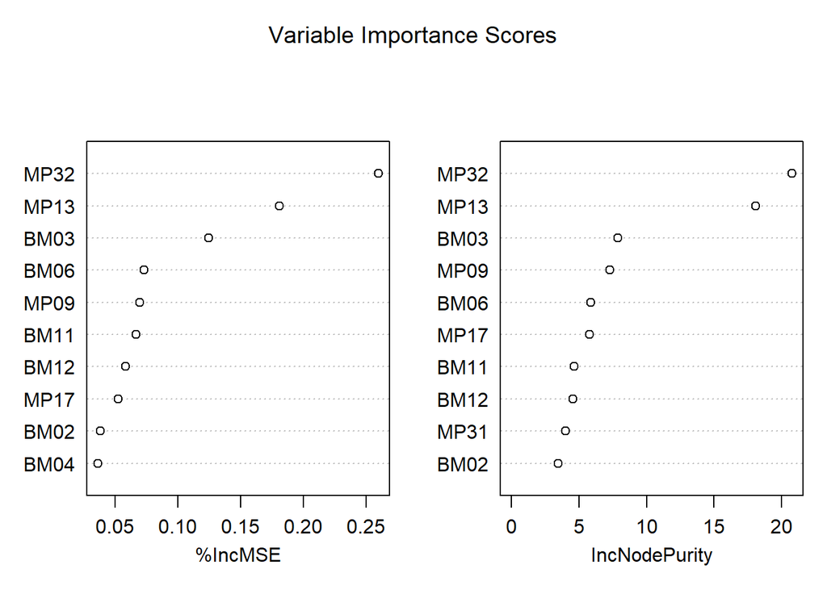

```r
varImpPlot(rfModel, main = 'Variable Importance Scores', scale = FALSE, n.var = 10, sort = TRUE)
```

3. Plot the optimal single tree with the distribution of yield in the terminal nodes. Does this view of the data provide additional knowledge about the biological or process predictors and their relationship with yield?

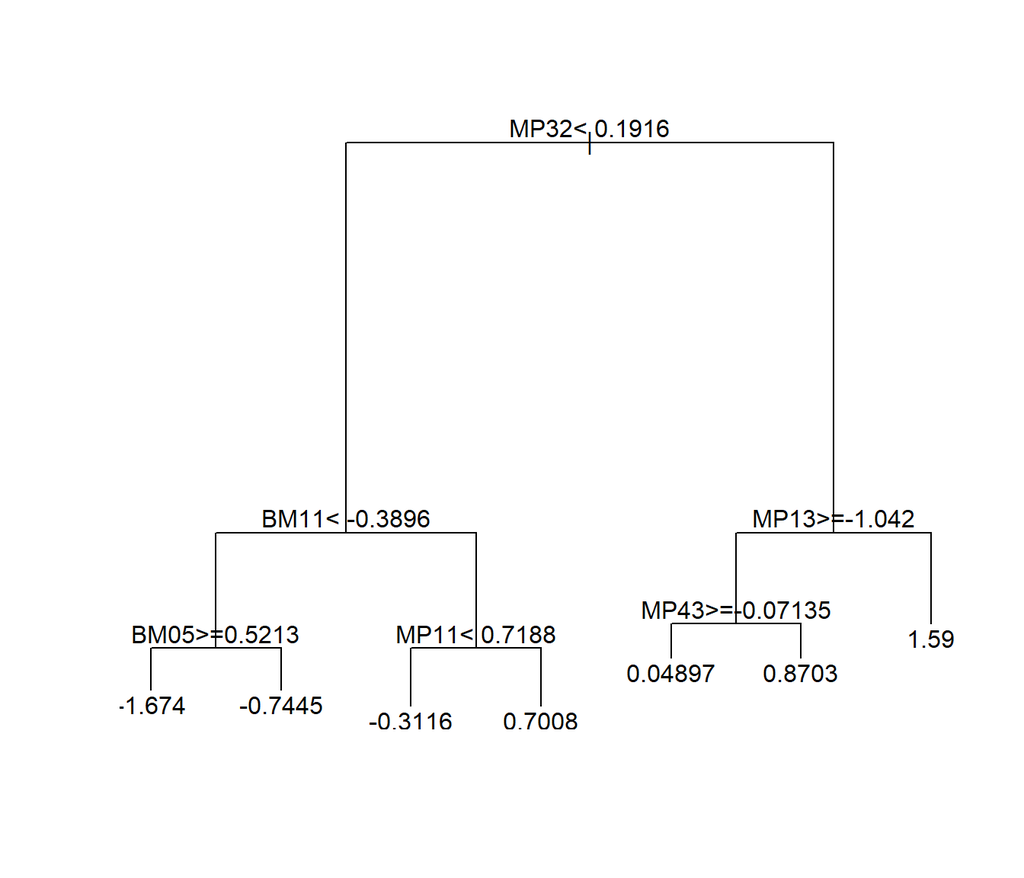

```r
plot(rpartTune$finalModel)
text(rpartTune$finalModel)
```